# 2016 Presidential Election Analysis

Varun Jaladi

5/16/2017

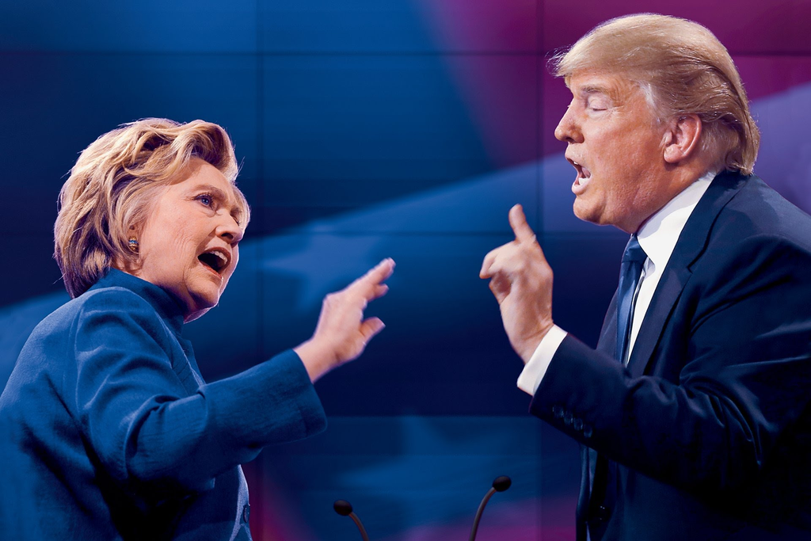

*Image from Huffington Post*

# Context

While America’s 58th presidential election divided the nation’s population, you’d be hard-pressed to find a single reputable poll predicting a win for the Republican nominee, Donald Trump, in late 2016.

Battling PR [blunder after blunder](http://www.huffingtonpost.com/entry/gary-herbert-trump-women_us_57f85540e4b0e655eab48044), the Trump campaign seemed to spiral out of control as election day drew nearer. Each week brought a new scandal, alienating a new demographic. That’s not to say the Clinton campaign was without its dark spots, however. Trump dug his heels in on growing concerns over an FBI investigation regarding Hillary Clinton’s private email server, and even [called into question](https://www.washingtonpost.com/politics/trump-tries-to-recover-by-going-after-clintons-past/2016/10/09/89c69008-8e2d-11e6-9c85-ac42097b8cc0_story.html?utm_term=.92721b8339b9) ex-president and hopeful “First Gentleman”, Bill Clinton.

Despite coming under fire, the outlook was bright for the Clinton campaign. In fact, even the most pessimistic models gave democratic nominee Hillary Clinton a ~70% chance of winning the election:

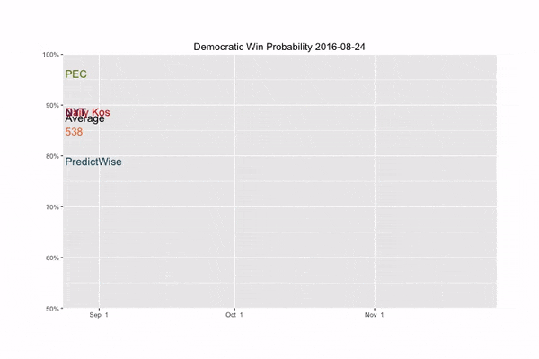

[*Source*](https://twitter.com/jshkatz/status/795837524308541440)

From statistics celeb Nate Silver’s [Fivethirtyeight](https://projects.fivethirtyeight.com/2016-election-forecast/), to the [New York Times](https://www.nytimes.com/interactive/2016/upshot/presidential-polls-forecast.html) and [LA Times](http://www.latimes.com/projects/2016-presidential-election-map/), the list of outlets predicting a Clinton win was endless.

When November 8th rolled by, the nation watched as one of the biggest upsets in the history of presidential elections unfolded before their eyes. Donald Trump defied predictions as he picked up electoral votes at a breakneck pace.

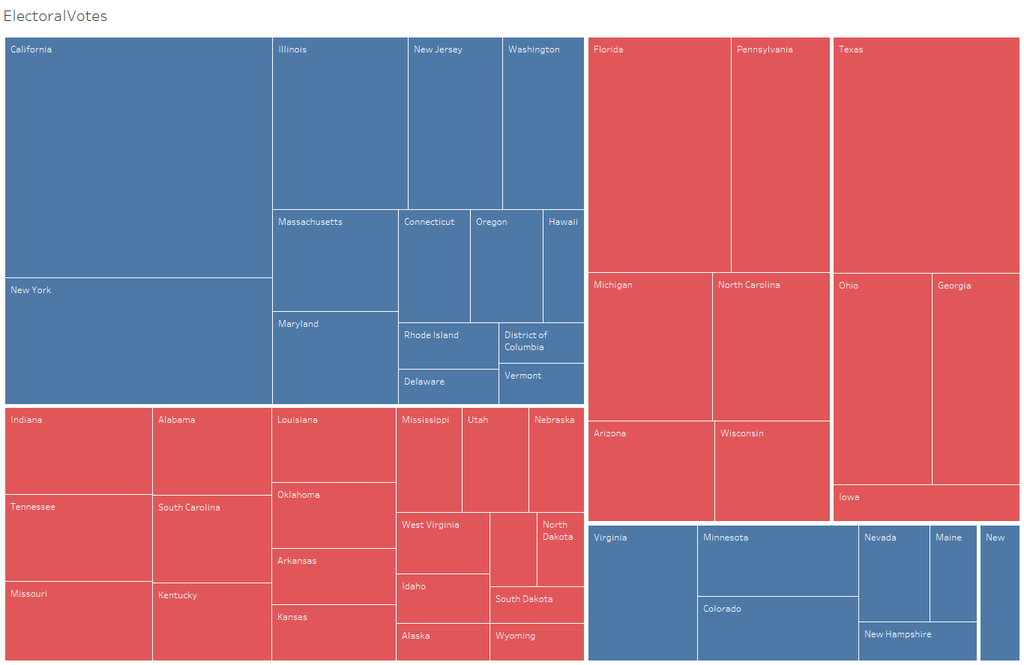

*Clinton: Blue, Trump: Red*

Final tally of electoral votes: Trump 306 - Clinton 232

Now, months after his victory and knee deep into the Trump administration, this analysis aims to investigate key characteristics of voters in this election, with the goal of better understanding why Clinton lost the 2016 election.

# Key Trends

## Income

A common storyline after the election was that Hillary lost the “middle class” vote. Historically, the Democratic party dominates the vote among lower income individuals. This tendency shifted during the 2016 election, as shown here among swing states:

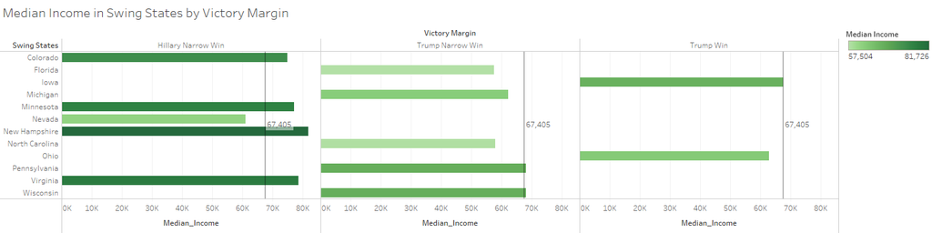

Almost all of the swing states were highly contentious (“Narrow Wins”), with only Iowa and Ohio being won comfortably by Trump (read more about victory margin classifications here in the notes about the data).

However, Trump did win in more swing states than Hillary, bagging 7 out of 12 states, which contributed in part to his significant electoral vote lead.

The trend holds when we include all states in the U.S., shown here grouped regionally:

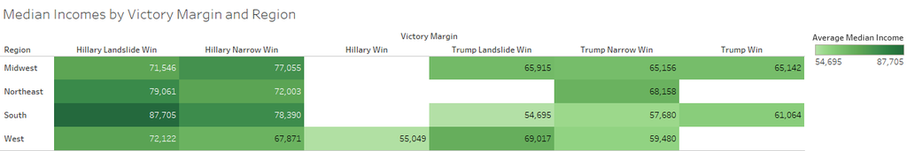

## Education

Hillary seemed to do well in more educated states. Comparing states by bachelor’s degree attainment, Trump dominated regions with relatively low attainment rates:

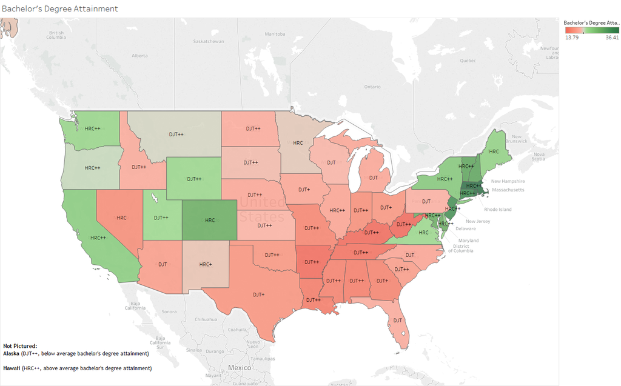

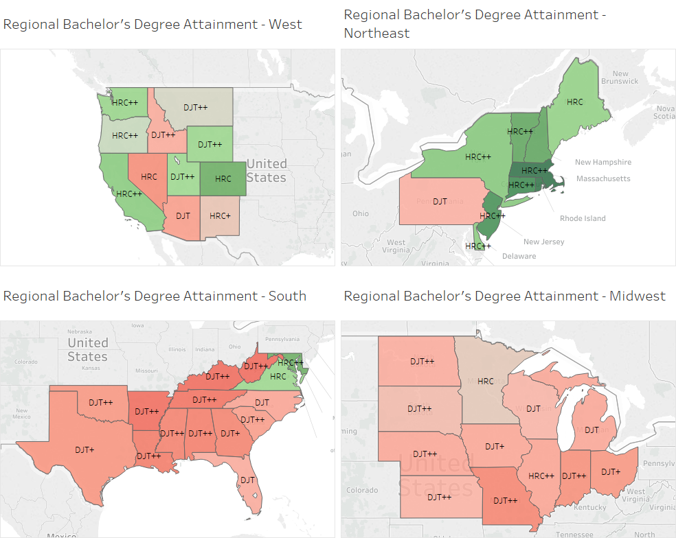

Extending our view to other education levels, the trend continues.

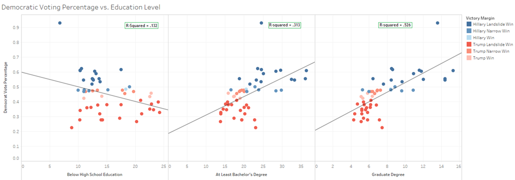

States with higher percentages of people without high school educations had less democratic votes, although with a weak correlation.

States with higher bachelor’s degree rates had a stronger correlation with more Democratic votes.

Graduate degree rates were the best predictor for Democratic vote percentages, with the highest R-squared value (.526) of the three education categories.

## Insurance

Given the candidates’ [disparate views on healthcare](http://www.npr.org/2016/11/02/500371785/platform-check-trump-and-clinton-on-health-care), it would be a reasonable assumption that uninsured voters would tend to support Clinton, who promised to uphold Obamacare. Surprisingly, this is not true:

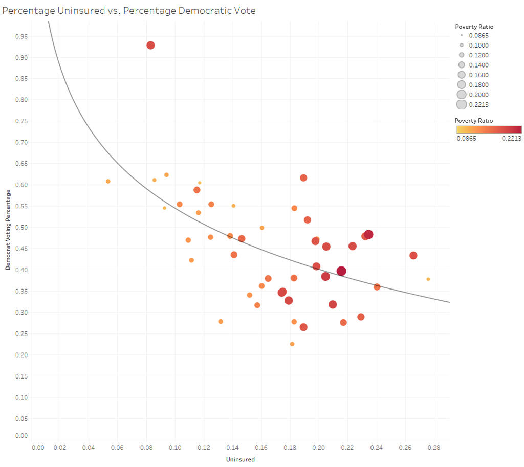

States with a higher uninsured population had less Democratic votes. However, when factoring in poverty in these states, we see a familiar trend emerge.

States with high amounts of poverty also tended to be uninsured, and poorer states tended to vote Republican in this election, as discussed in the “Income” section above.

We can confirm this relationship by looking at uninsurance and income:

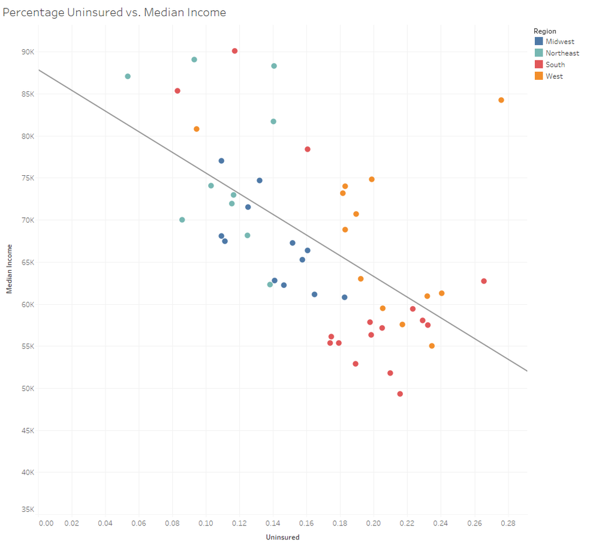

As expected, lower incomes generally mean less insured people. Despite Hillary’s more progressive insurance plan, low income individuals did not for her.

## Race

While the Democratic Party often controls the minority vote, race didn’t have a strong role in this election.

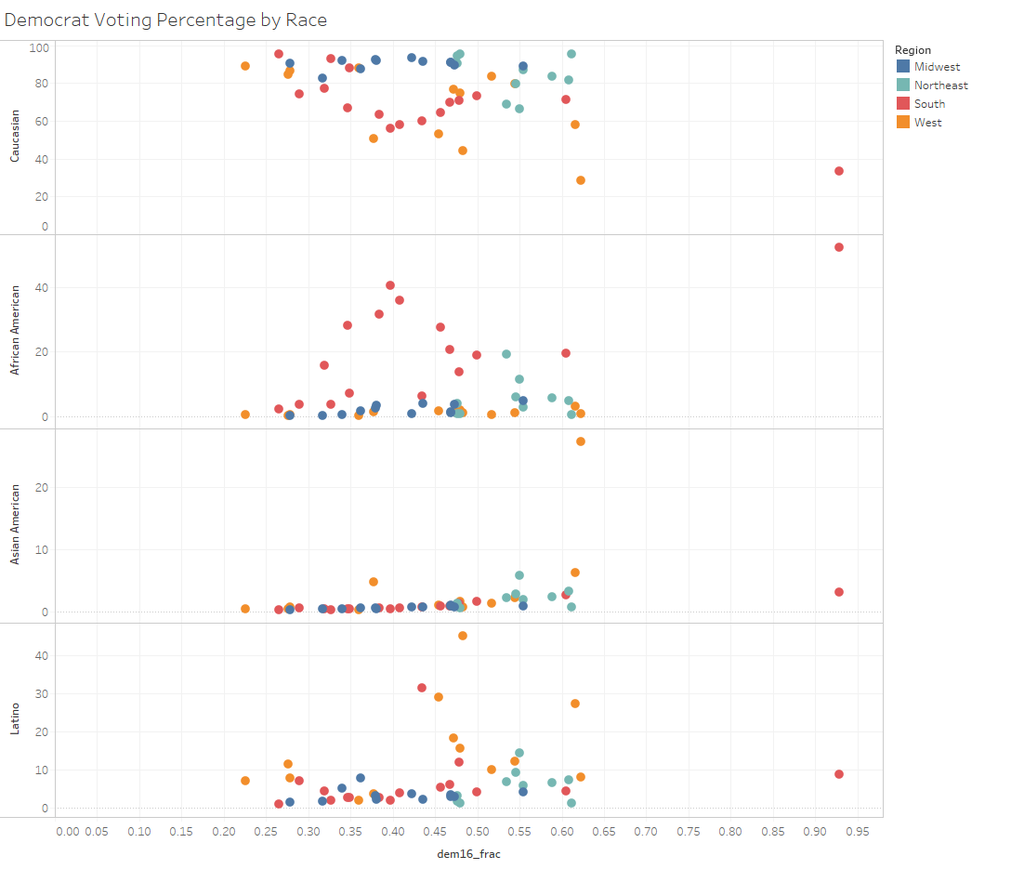

Most minority groups are consistently spread out with respect to Democratic voting percentages.

This is consistent with reports that Clinton was [unable to rally minority voters](https://www.nytimes.com/2016/09/05/us/politics/young-blacks-voice-skepticism-on-hillary-clinton-worrying-democrats.html).

## Voter Engagement

While certain demographics may not have shown up at the polls, voter engagement was fairly even between states, regardless of the winning candidate.

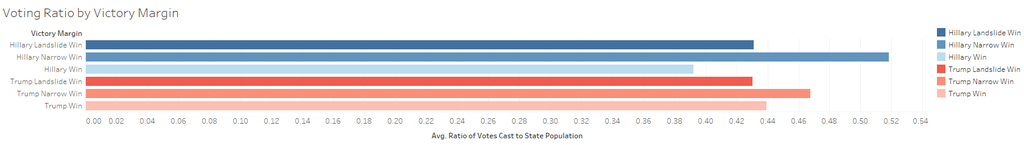

*Note: Voting Ratio is calculated based on total population of a state, not by registered voters, as “voter turnout” is usually calculated.*

Additionally, while poverty was a large indicator of voting in this election, there is no relationship between poverty and voter engagement here. Neither candidate won states due to lack of turnout:

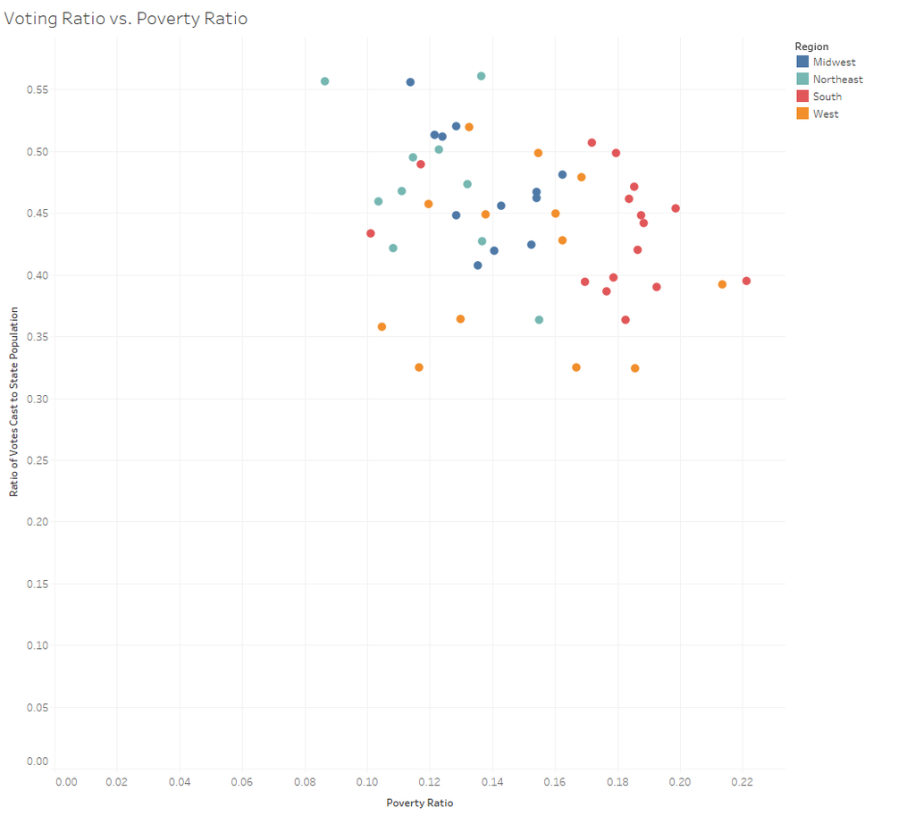

## Conclusion

The Clinton campaign lost the vote of the “average American”, while winning among more highly educated and wealthier populations (although our analysis did not touch on the voting tendencies of the “ultra rich”).

Despite having policies that were arguably better for poorer individuals (such as in the case of health care), Hillary lost many votes from this traditionally Democratic voting block, who showed up in record numbers for Obama in 2008 but were uninspired by the Clinton campaign.

Should Clinton run against Trump again in 2020, the key takeaways for her campaign to regain the working class vote are:

**1. A more focused economic message**

As a part of a bigger focus on social equity and diversity, Clinton’s campaign stressed wealth redistribution and increased benefits.

*“Despite what you hear, we don’t need to make America great again. America has never stopped being great. But we do need to make America whole again. Instead of building walls, we need to be tearing down barriers,” Clinton said.* [Source](http://www.politico.com/blogs/2016-dem-primary-live-updates-and-results/2016/02/hillary-clinton-donald-trump-slogan-219908)

While these goals resonated with her already firm base of the educated and financially secure, an emphasis on job creation may have captured the attention of the lower/lower-middle class more strongly.

Trump’s campaign promises of manufacturing jobs and protectionism was much more convicing to those worried about economic and job outlook.

After all, if you’ve been worried about keeping your job and paying your bills, would you rather hear Trump say he’ll “Make America Great Again”, or hear Hillary say “we don’t need to make America great again”?

**2. Image control**

While both candidates were wealthy, Clinton allowed herself to be painted as the candidate representing wealthy interests.

While she struck back by calling out Trump’s inexperience and bigotry in the debates, Clinton rarely contested the idea that she was out of touch with the working class. Had she attacked Trump on being born into extreme wealth and being handed millions of dollars, she might have regained some of her image in the eyes of the working class.

# The Data

## Access the Data

All relevant data is hosted publically [here on data.world](https://data.world/vcjaladi/2016-elections-data) as well as [here on Github](https://github.com/vcjaladi/ElectionAnalysis).

## Notes

1. The primary dataset was aggregated from county level info, so all ratios are averages of county percentages. For example, Texas is listed as having an uninsured rate of 26.6%. Here, this means that the “average” or typical Texas county has 26.6% people uninsured, NOT that 26.6% of all Texans are uninsured. This caveat is not true of the democratic/republican vote percentages, which were taken directly from the [Politico elections result report](http://www.politico.com/2016-election/results/map/president).
2. Some metrics used frequently in our analysis do not appear in our dataset. The most prominent of these metrics is “Victory Margin”, which is the margin a candidate won a state by, divided into categories. The cutoffs are arbitrary, but help to see how many states were closely competitive, mildly competitive, or not competitive at all. The calculation is shown in the following formula:

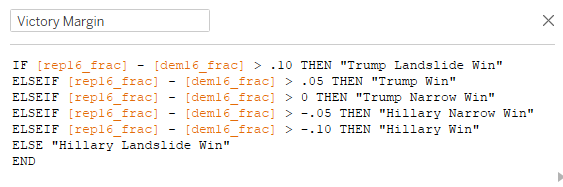

3. Other calculated metrics that are not in our dataset, such as Poverty Ratio and Voter Ratio, are simple normalizations so that we may compare across states with disparate populations. For example, Poverty Ratio is the number of people in poverty in a state divided by the total population of that state.
4. The remaining data was collected by the New York Times and The Ulster Institute for Social Research for a publication in the *Open Quantitative Sociology & Political Science* journal in 2016. Also included are extracts from the 2015 Census Data datasets for income, poverty, and race that were joined to the elections data set. The sources for these extracts can be found on the [U.S. Census Bureau’s data.world profile](https://data.world/uscensusbureau).

## Interactive Visualizations (Shiny)

The interactive visualizations can be accessed [here](https://varunjaladi.shinyapps.io/elections_-_interactive_visualizations/), with instructions for the interactions at the top of each page.